# Final Assignment

Due 1/8/2018

**Instructions:**  
1. Please rename your final assignment rmd file as - `finalAssign_name.rmd`.  
2. Fill in your code in the relevant code execution boxes.  
3. Please avoid plagiarism - do not share your answers with other students!  
4. Use the encryption guide (see moodle) to encrypt your final rmd file and name it `finalAssign_name_rmd_crypt`  
5. Use the encryption guide to encrypt also your HTML file and name it `finalAssign_name_html_crypt`  
6. Upload the encrypted files to the following link:  
`https://github.com/DataScienceHU/DataAnalysisR/tree/master/finalAssignment/finalAssignment_submission/`

# 52414 Final Assignment

[figure not shown]

**The final assignment is based on an article published by [*FiveThirtyEight*](http://fivethirtyeight.com/). In the article, the author investigated differences between male and female superheroes in comic books: [*Comic Books Are Still Made By Men, For Men And About Men*](https://fivethirtyeight.com/features/women-in-comic-books/). In this assignment, you will not only try to reproduce some of the findings with a more up-do-date data, but will also dive deeper into the data to provide meaningful insights backed by statistical analysis.**

1. Do not use libraries outside of the required libraries.
2. It is recommended to read the 538 article.

### 1) Data Loading and Cleaning

### Loading data

```r
heroes <- read.csv("C:/Ran/R/Advance Course/FINAL/heroes.csv", stringsAsFactors=FALSE)
powers <- read.csv("C:/Ran/R/Advance Course/FINAL/powers.csv", stringsAsFactors=FALSE)
```

*Load the `heroes`,`powers`, and the `details` datasets.*

1. Using kable, show the first 10 rows of the `heroes` dataframe.

```r
heroes <- heroes[,-1]
knitr::kable(head(heroes,10),caption="Heroes List (first 10 rows)")
```

Heroes List (first 10 rows)

[output not shown]

```r
type_99 = vector()
type_hyphen = vector()
for(i in 1:ncol(heroes)){
  type_99[i] = sum(str_count(heroes[,i], "-99"),na.rm = T)
  type_hyphen[i] = sum(str_count(heroes[,i], "-"),na.rm = T)
}
count = cbind(type_99,type_hyphen)
colnames(count) = c("-99 count", " - count")
rownames(count) = c("column 1", "column 2","column 3","column 4","column 5","column 6", "column 7","column 8","column 9","column 10")
kable(count)
```

|  | -99 count | - count |
| --- | --- | --- |
| column 1 | 0 | 55 |
| column 2 | 0 | 29 |
| column 3 | 0 | 172 |
| column 4 | 0 | 312 |
| column 5 | 0 | 172 |
| column 6 | 217 | 217 |
| column 7 | 0 | 20 |
| column 8 | 0 | 663 |
| column 9 | 0 | 7 |
| column 10 | 237 | 237 |

3. We would like to replace all of the above instances. Write another script that goes over the columns and replaces all the `-` to `otherNA` and `-99` to `NA`. Using kable, show the first 10 rows of the resulting dataframe.

```r
###Data Perparation
for(i in 1:ncol(heroes)){
  heroes[,i][str_count(heroes[,i], "-99") == 1] = "NA"
  heroes[,i][str_count(heroes[,i], "-") == 1] = "otherNA"
}
```

```r
knitr::kable(head(heroes,10),caption="Heroes List (first 10 rows)")
```

Heroes List (first 10 rows)

[output not shown]

4. Currently, the `details` data is loaded as a character vector. Parse the vector and transalte it into a dataframe containing two columns: power_name(chr) and power_score(double).

```r
details <- read_delim("details.txt", "+",
     escape_double = FALSE, col_names = c("power_name" ,"power_score"),
     trim_ws = TRUE)
colnames(details) = c("Power name", "Power score")
head(details)
```

```
## # A tibble: 6 x 2
##   `Power name`        `Power score`
##   <chr>                       <dbl>
## 1 Ability Shift                 0.5
## 2 Absorption                    2
## 3 Accelerated Healing           5
## 4 Adaptation                    0.5
## 5 Agility                       0.5
## 6 Animal Attributes             0.5
```

### 2) Exploratory Data Analysis

**We are going to concetrate our analysis on the gender disparity and representation of Comics superheroes.**

1. Make a plot of the gender distribution (total, not intersected with any other variable).

```r
my_dat <- heroes %>%
  group_by(heroes$Gender) %>%
  summarise(counts = n())
```

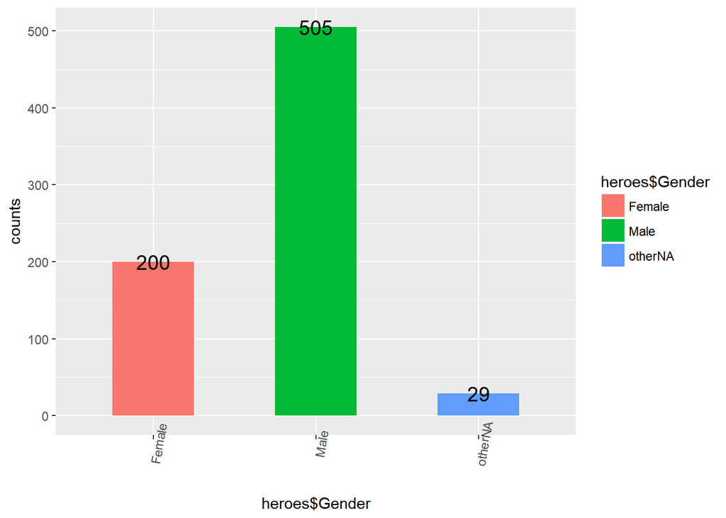

```r
bp<- ggplot(my_dat, aes(x=`heroes$Gender`, y=counts, fill=`heroes$Gender`))+
geom_bar(width = 0.5, stat = "identity")+
geom_text(aes(label=counts), size = 5)+
theme(axis.text.x = element_text(angle = 80, hjust = 0.5))+
geom_area(position = 'stack')
bp
```

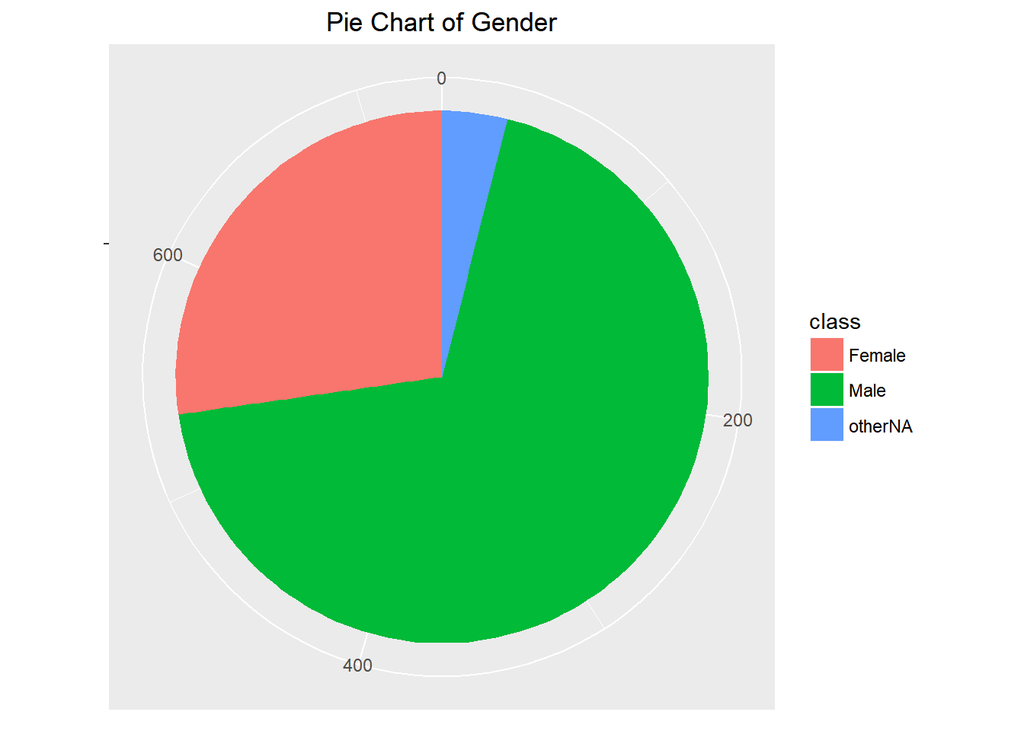

```r
pie <- ggplot(heroes, aes(x = "", fill = factor(heroes$Gender))) +
  geom_bar(width = 1) +
  theme(axis.line = element_blank(),
  plot.title = element_text(hjust=0.5)) +
  labs(fill="class",
  title="Pie Chart of Gender", x=NULL,y = NULL)


pie + coord_polar(theta = "y",start = 0, direction = 1)
```

*Run the script in the box below. We can see that ‘DC Comics’ & ‘Marvel Comics’ are the two major players in the comics industry. Let’s focus our analysis on these two companies.*